# 强耦合同化中的局地化研究——以多尺度洛伦茨模式为例

> Shen, Z. , Tang, Y., Li, X., Gao, Y.,(2021) On the localization in strongly coupled ensemble data assimilation using a two-scale Lorenz model, Earth and Space Science

耦合资料同化具有非常大的潜力来为气候预报提供初始条件，减少初始化冲击，改善气候预报的水平。在耦合模式的资料同化中，观测资料被同化到一个或多个模型组件中，并且直接（通过同化）或者间接（通过耦合模式积分）地在不同组件之间交换信息。根据耦合模式不同组件之间信息传递的不同方式，耦合资料同化可以分为两种：强耦合同化（SCDA）和弱耦合同化（WCDA）。在弱耦合同化中，分析增量分别在各模型组件中被计算和应用。与之相反，强耦合同化使用全耦合的误差协方差来计算观测增量，并应用到整个耦合模式的所有模式组件中。强耦合同化可以充分利用观测信息更新模式，并且有助于提供动力协调的耦合模式预报初值，具有非常大的应用潜力。但是当前的强耦合同化方法还不完善，整体上还处于研究阶段，距离业务化还有很远的距离。

耦合模式的不同成分（如海洋、大气）具有不同的时空尺度，因此用于跨成分更新的耦合协方差矩阵较难估计，往往需要使用非常巨大的集合才能使得强耦合的效果超过弱耦合，这也强耦合同化的主要技术挑战之一。本文提出了一种通过耦合协方差的局地化来改进强耦合同化的方法。为了抑制因集合成员数量不足而造成的远距离虚假相关，局地化是集合卡尔曼滤波器同化中的重要方法。为了处理不同耦合成分的不同时空尺度，本文发展了新的跨耦合成分协方差的局地化公式。基于使用理想的多尺度洛伦茨96模式，本文开展了孪生实验，验证了新的局地化方法在于改进强耦合同化效果方面的功效。

整个实验的脚本和结果如下：

# 1. 初始化阶段

## 1.1 定义模式

实验使用的是多尺度洛伦茨96模式

\begin{equation} \frac{dX_k}{dt}=X_{k-1} (X_{k+1}-X_{k-2} )-X_k+F-\frac{hc}{b}\sum\limits_{j=1}^{J} Z_{j,k},\\ \frac{dZ_{j,k}}{dt}=cbZ_{j+1,k} (Z_{j-1,k}-Z_{j+2,k} )-cZ_{j,k}+\frac{hc}{b} X_k, \end{equation}

方程的两个变量X和Z分别对应大尺度和小尺度的大气变量，通过耦合项耦合在一起。ODE使用RK-45格式进行求解，对应模式积分。 参数方面：K代表X变量数目，也就是将一个维度环K等分的区域平均值；J代表每个K区域内含有J个子区域，也就是一个X与J个Z变量耦合在一起。F是外强迫，c和b是时空尺度比，h是耦合强度。这里使用默认数值如下：

```python
# In[model_def]
import numpy as np;
class msL96_para:
    name = 'multi-scale Lorenz 96 model parameter'
    K = 36; J = 10; F = 8;
    c = 10; b = 10; h = 1

def Lmodel_rhs(x,Force):
    dx = (np.roll(x,-1)-np.roll(x,2))*np.roll(x,1)-x + Force
    return dx

def Smodel_rhs(z,Force):
    Para = msL96_para()
    c = Para.c; b = Para.b
    dz = c*b*(np.roll(z,1)-np.roll(z,-2))*np.roll(z,-1)-c*z + Force
    return dz

def msL96_rhs(Y):
    Para = msL96_para()
    K = Para.K; J = Para.J
    c = Para.c; b = Para.b; h = Para.h;

    X = Y[range(K)]
    Z = Y[range(K,len(Y))]
    #
    SumZ = np.sum(np.reshape(Z,(K,J)),axis=1)
    forcing_X = Para.F - h*c/b*SumZ
    dX = Lmodel_rhs(X,forcing_X)

    forcing_Z = h*c/b*np.kron(X,np.ones(J))
    dZ = Smodel_rhs(Z,forcing_Z)
    dY = np.concatenate((dX,dZ),axis=0)
    return dY

def RK45(x,func,h):
    #
    K1=func(x);
    K2=func(x+h/2*K1);
    K3=func(x+h/2*K2);
    K4=func(x+h*K3);
    x1=x+h/6*(K1+2*K2+2*K3+K4);
    return x1

def msL96_adv_1step(x0,delta_t):
    #
    x1=RK45(x0,msL96_rhs,delta_t)
    return x1
```

## 1.2 设定实验参数

包括同化时长，X和Z变量的不同同化频率，特别地，小尺度的Z变量每隔若干个（这里是2个）被观测到一个，这在线性观测算子上体现。

```python
# In[expr setting]: Data assimilation parameters
assim_period_steps = 8000;
assimS_every_n_steps = 5      # data assimilation every 3h (5 steps)
assimL_every_n_steps = 40;    # data assimilation every 1d (40 steps)
obs_every_n_Svars = 2;        # 1 of every 2 S-model variable can be observed

Para = msL96_para()
K = Para.K
J = Para.J
H_matL = np.eye(K);
H_matS = np.eye(K*J)
H_matS = H_matS[0:K*J:obs_every_n_Svars,:];
def H_op(x,H_mat):
    y = np.dot(H_mat,np.transpose(x))
    return y
H_all = np.eye(K*J+K)
H_useLobs=H_all[range(K)]
H_useSobs=H_all[K:(K*J+K):obs_every_n_Svars]
case_dir = "/media/zqshen/Samsung_T5/EAKFmsL96pythonDATA&result/EAKF_python_CDA/"
import os
```

## 1.3 进行spin-up以获得稳定初值

```python
# In[spinup]: spin up
delta_t=0.005;
Para = msL96_para()
K = Para.K
J = Para.J
if not os.path.exists(case_dir+'DATA/spinup_data.npz'):
    x0spinup=np.random.randn(K+K*J);
    t=0;
    spinup_steps = 14600;
    x1 = x0spinup;
    for t in range(spinup_steps):
        x2=msL96_adv_1step(x1,delta_t);
        x1=x2;
    x0true = x2;
    del x1
    del x2
    print('finish spinup and save data');
    np.savez(case_dir+'DATA/spinup_data.npz',x0=x0true,dt=delta_t);
else:
    SPDT = np.load(case_dir+'DATA/spinup_data.npz');
    x0true = SPDT['x0']
    delta_t = SPDT['dt']
    print('load x0ture and delta_t');
```

```
load x0ture and delta_t
```

## 1.4 模拟观测数据和真实场

使用spin-up获取的初值作为真实场的初值，积分得到真实场用以结果的检验。观测通过在观测时间和观测点上增加高斯分布的观测误差来模拟。针对不同尺度的模式，使用不同的观测误差标准差，即针对两个耦合成分的长期标准差乘上一个系数获得。

```python
# In[truth&obs]
### generate the truth and observation
if not os.path.exists(case_dir+'DATA/true_data.npz'):
    XtrueL = np.zeros([assim_period_steps,K])
    XtrueS = np.zeros([assim_period_steps,K*J])
    OBS_L = np.zeros([assim_period_steps//assimL_every_n_steps,K])
    OBS_S = np.zeros([assim_period_steps//assimS_every_n_steps,K*J//obs_every_n_Svars]);

    x1 = x0true;
    for t in range(assim_period_steps):
        x2=msL96_adv_1step(x1,delta_t);
        XtrueL[t]=x2[range(K)];
        XtrueS[t]=x2[range(K,len(x2))]
        if t%assimS_every_n_steps==0:
            OBS_S[t//assimS_every_n_steps]=H_op(XtrueS[t],H_matS);
        if t%assimL_every_n_steps==0:
            OBS_L[t//assimL_every_n_steps]=H_op(XtrueL[t],H_matL);
        x1=x2;
    del x1
    del x2
    STD_L = np.std(XtrueL,axis=0);  err_L = 0.3*np.mean(STD_L)
    STD_S = np.std(XtrueS,axis=0);  err_S = 0.3*np.mean(STD_S)
    OBS_L = OBS_L + err_L*np.random.randn(len(OBS_L),len(OBS_L[0]))
    OBS_S = OBS_S + err_S*np.random.randn(len(OBS_S),len(OBS_S[0]))
    print('Experimental data generated')
    np.savez(case_dir+'DATA/true_data.npz',x0=x0true,dt=delta_t,Ltrue=XtrueL,Strue=XtrueS,Lobs=OBS_L,Sobs=OBS_S,Lstd=err_L,Sstd=err_S);
else:
    TRDT = np.load(case_dir+'DATA/true_data.npz')
    x0true = TRDT['x0']
    delta_t = TRDT['dt']
    XtrueL = TRDT["Ltrue"]
    XtrueS = TRDT["Strue"]
    OBS_L = TRDT["Lobs"]
    OBS_S = TRDT["Sobs"]
    err_L = TRDT["Lstd"]
    err_L = err_L**2
    err_S = TRDT["Sstd"]
    err_S = err_S**2  # std to var
    print('load truth and observation data')
```

```
load truth and observation data
```

## 1.5 真实场画图

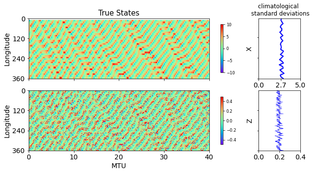

```python
pltcmap = plt.cm.rainbow
plt.figure(figsize=(10,5))
grid = plt.GridSpec(2, 6, wspace=0.1, hspace=0.2)
plt.subplot(grid[0,0:5])
[xx,yy]=np.meshgrid(np.arange(0,8000)*delta_t,range(10,370,10))
plt.pcolormesh(xx,yy,XtrueL[range(0,8000),:].T,cmap=pltcmap)
plt.xticks(np.arange(0,8500,2000)*delta_t,[])
plt.yticks(np.arange(0,420,120),fontsize=14)
plt.clim(-10,10)
plt.title('True States',fontsize=15)
plt.ylabel('Longitude',fontsize=14)
ax = plt.gca()
ax.invert_yaxis()
cb=plt.colorbar(shrink=0.8)
cb.ax.tick_params(labelsize='small')

plt.subplot(grid[1,0:5])
[xxx,yyy] = np.meshgrid(np.arange(0,8000)*delta_t,range(1,361))
plt.pcolormesh(xxx,yyy,XtrueS[range(0,8000),:].T,cmap=pltcmap)
plt.xticks(np.arange(0,8500,2000)*delta_t,fontsize=14)
plt.yticks(np.arange(0,420,120),fontsize=14)
plt.clim(-0.5,0.5)
plt.ylabel('Longitude',fontsize=14)
ax = plt.gca()
ax.invert_yaxis()
cb = plt.colorbar(shrink=0.8)
cb.ax.tick_params(labelsize='small')
plt.xlabel('MTU',fontsize=14)

plt.subplot(grid[0,5])
plt.plot(STD_L,range(10,370,10),'b',lw=2)
plt.yticks(np.arange(120,420,120),[])
plt.ylabel('X',fontsize=14)
plt.xticks([0,2.7,5],fontsize=14);plt.grid(axis='x')
plt.xlim(0,5);plt.ylim(10,360)
plt.title('climatological \n standard deviations')
ax = plt.gca()
ax.invert_yaxis()

plt.subplot(grid[1,5])
plt.plot(STD_S,range(1,361),'b',lw=.5)
plt.yticks(np.arange(0,420,120),[])
plt.xlim(0,0.4);plt.ylim(1,360)
plt.xticks([0,0.2,0.4],fontsize=14);plt.grid(axis='x')
plt.ylabel('Z',fontsize=14)
ax = plt.gca()
ax.invert_yaxis()
```

从上图的真实场结果中很容易看到多尺度。X变量的分辨率较低，时间变化较慢。 此外，根据模型方程，X变量倾向于向西传播，Z变量倾向于向东传播，相速度较大。由于等式2中的耦合项，Z变量被限制在具有大X值的区域，并且在离开这些区域时迅速消失。方程1中的耦合项也影响X变量的振幅。X模型和Z模型的相互作用产生了X模型的几个活跃区域，这些活跃区域的变化更为剧烈，如Lorenz在他的原著中所示。

# 2. 局地化敏感性实验

## 2.1 定义单模式

为了通过敏感性实验确定每个耦合成分的局地化系数，通过将另一成分使用真实场代替的方法定义单模式积分方法如下

```python
# In[def_singlemodel]:
def Lmodel_adv_1step(x0,delta_t,XtrueS,t):
    Para = msL96_para()
    K = Para.K; J = Para.J
    c = Para.c; b = Para.b; h = Para.h;
    # use truth as forcing
    SumZ = np.sum(np.reshape(XtrueS[t],(K,J)),axis=1)
    forcing_X = Para.F - h*c/b*SumZ
    Lmodel_rhs_noncp = lambda x: Lmodel_rhs(x,forcing_X)
    x1=RK45(x0,Lmodel_rhs_noncp,delta_t)
    return x1
def Smodel_adv_1step(x0,delta_t,XtrueL,t):
    Para = msL96_para()
    J = Para.J
    c = Para.c; b = Para.b; h = Para.h;
    #
    forcing_Z = h*c/b*np.kron(XtrueL[t],np.ones(J))
    Smodel_rhs_noncp = lambda x: Smodel_rhs(x,forcing_Z)
    x1=RK45(x0,Smodel_rhs_noncp,delta_t)
    return x1
```

## 2.2 定义EAKF算法

其中的EAKF算法和自适应inflation来自于Jeffery Anderson（2003,2011）

EAKF算法使用局地化来避免虚假遥相关，即在增加观测增量的时候乘以一个因子$\rho$ \begin{equation}\label{eakf_update} x_{m,n} = x_{m,n}^{(p)}+\rho*\Delta x_{m,n}, n=1,\ldots,N \end{equation}

$\rho$使用Gaspri-Cohn公式计算，如下

其中的参数c用于控制截断长度，d是观测点到模式更新点之间的距离

```python
# localization factor
def comp_cov_factor(z_in,c):
    z=abs(z_in);
    if z<=c:
        r = z/c;
        cov_factor=((( -0.25*r +0.5)*r +0.625)*r -5.0/3.0)*r**2 + 1.0;
    elif z>=c*2.0:
        cov_factor=0.0;
    else:
        r = z / c;
        cov_factor = ((((r/12.0 -0.5)*r +0.625)*r +5.0/3.0)*r -5.0)*r + 4.0 - 2.0 / (3.0 * r);
    return cov_factor;
# observation increment for the observation site
def obs_increment_eakf(ensemble, observation, obs_error_var):
    prior_mean = np.mean(ensemble);
    prior_var = np.var(ensemble);
    if prior_var >0.001:
        post_var = 1.0 / (1.0 / prior_var + 1.0 / obs_error_var);
        post_mean = post_var * (prior_mean / prior_var + observation / obs_error_var);
    else:
        post_var = prior_var;
        post_mean = prior_mean;

    updated_ensemble = ensemble - prior_mean + post_mean;

    var_ratio = post_var / prior_var;
    updated_ensemble = np.sqrt(var_ratio) * (updated_ensemble - post_mean) + post_mean;

    obs_increments = updated_ensemble - ensemble;
    return obs_increments
# regression the obs_inc to model grid corresponds state_ens
def get_state_increments(state_ens, obs_ens, obs_incs):
    covar = np.cov(state_ens, obs_ens);
    state_incs = obs_incs * covar[0,1]/covar[1,1];
    return state_incs
# the following for adaptive inflation
def compute_new_density(dist_2, sigma_p_2, sigma_o_2, lambda_mean, lambda_sd, gamma, lambda_in):
    exponent_prior = - 0.5 * (lambda_in - lambda_mean)**2 / lambda_sd**2;
    # Compute probability that observation would have been observed given this lambda
    theta_2 = (1.0 + gamma * (np.sqrt(lambda_in) - 1.0))**2 * sigma_p_2 + sigma_o_2;
    theta = np.sqrt(theta_2);
    exponent_likelihood = dist_2 / ( -2.0 * theta_2);
    # Compute the updated probability density for lambda
    # Have 1 / sqrt(2 PI) twice, so product is 1 / (2 PI)
    density = np.exp(exponent_likelihood + exponent_prior) / (2.0 * np.pi * lambda_sd * theta);
    return density

def update_inflate(x, sigma_p_2, obs, sigma_o_2, inflate_prior_val, lambda_mean, gamma,lambda_sd):
    lambda_mean_LB = 1.0
    lambda_mean_UB = 1.3
    lambda_sd_LB = 0.5

    # FIRST, update the inflation mean:
    # Get the "non-inflated" variance of the sample
    # lambda here, is the prior value before the update.
    sigma_p_2 = sigma_p_2/(1+gamma*np.sqrt(inflate_prior_val)-1)**2
    dist_2 = (x - obs)**2        # Squared-innovation
    theta_bar_2 = ( 1 + gamma * (np.sqrt(lambda_mean) - 1) )**2 * sigma_p_2 + sigma_o_2;
    theta_bar    = np.sqrt(theta_bar_2);
    u_bar        = 1 / (np.sqrt(2 * np.pi) * theta_bar);
    like_exp_bar = - 0.5 * dist_2 / theta_bar_2;
    v_bar        = np.exp(like_exp_bar);

    gamma_terms  = 1 - gamma + gamma*np.sqrt(lambda_mean);
    dtheta_dinf  = 0.5 * sigma_p_2 * gamma * gamma_terms / (theta_bar * np.sqrt(lambda_mean));

    like_bar     = u_bar * v_bar;
    like_prime   = (like_bar * dtheta_dinf / theta_bar) * (dist_2 / theta_bar_2 - 1);
    like_ratio   = like_bar / like_prime;

    # Solve a quadratic equation
    a = 1;
    b = like_ratio - 2*lambda_mean;
    c = lambda_mean**2 - lambda_sd**2 - like_ratio*lambda_mean ;

    o = np.max( [ np.abs(a), np.abs(b), np.abs(c) ] );
    a = a/o;
    b = b/o;
    c = c/o;
    d = b**2 - 4*a*c;
    if b < 0:
        s1 = 0.5 * ( -b + np.sqrt(d) ) / a;
    else:
        s1 = 0.5 * ( -b - np.sqrt(d) ) / a;

    s2 = ( c/a ) / s1;

    if np.abs(s2 - lambda_mean) < np.abs(s1 - lambda_mean):
        new_cov_inflate = s2;
    else:
        new_cov_inflate = s1;

    if new_cov_inflate < lambda_mean_LB or new_cov_inflate > lambda_mean_UB or np.isnan(new_cov_inflate):
        new_cov_inflate = lambda_mean_LB;
        new_cov_inflate_sd = lambda_sd;
        return new_cov_inflate,new_cov_inflate_sd
    if lambda_sd <= lambda_sd_LB:
        new_cov_inflate_sd = lambda_sd;
        return new_cov_inflate,new_cov_inflate_sd
    else:
        new_max = compute_new_density(dist_2, sigma_p_2, sigma_o_2, lambda_mean, lambda_sd, gamma, new_cov_inflate);

        # Find value at a point one OLD sd above new mean value
        new_1_sd = compute_new_density(dist_2, sigma_p_2, sigma_o_2, lambda_mean, lambda_sd, gamma, new_cov_inflate + lambda_sd);

        ratio = new_1_sd / new_max;
        # Can now compute the standard deviation consistent with this as
        # sigma = sqrt(-x^2 / (2 ln(r))  where r is ratio and x is lambda_sd (distance from mean)
        new_cov_inflate_sd = np.sqrt( - 0.5 * lambda_sd**2 / np.log(ratio) );
    return new_cov_inflate, new_cov_inflate_sd

def eakf_analysis(ensemble_in,obs_in,obs_error_var,H_mat,obs_every_n_vars,local_para,inf_in,H_op):
    inf_cov = 0.6           #  fix the cov_inf_std
    N = len(ensemble_in)
    L = len(ensemble_in[0]);     # model dimension (model grids)
    m = len(obs_in);    # number of obs sites
    # prior inflation with inf_in (spatial adaptive)
    ens_mean = np.mean(ensemble_in,axis=0)
    for n in range(N):
        ensemble_in[n] = inf_in*(ensemble_in[n]-ens_mean)+ens_mean
    lambda_i = inf_in.copy()
    for i in range(m):
        ensemble_proj = H_op(ensemble_in,H_mat);
        obs_proj = ensemble_proj[i];   # project model grid to obs site
        obs_inc = obs_increment_eakf(obs_proj,obs_in[i],obs_error_var);
        for j in range(L):
#            state_inc=get_state_increments(ensemble_in[:,j],obs_proj,obs_inc);
            covar = np.cov(ensemble_in[:,j], obs_proj);
            r = covar[0,1]/covar[1,1]

            dist = np.abs(obs_every_n_vars*i-j);
            if dist>L/2.0:
                dist=L-dist;
            cov_factor = comp_cov_factor(dist,local_para);
#             update inf
            if r*cov_factor>0.0001:
                lambda_i[j], new_cov_inf_sd = update_inflate(np.mean(obs_proj), np.var(obs_proj), obs_in[i], obs_error_var,inf_in[j], lambda_i[j], r*cov_factor,inf_cov)
            # update ensemble
            ensemble_in[:,j]=ensemble_in[:,j]+r*cov_factor*obs_inc;
    ensemble_out = ensemble_in;
    inf_out = lambda_i
#    inf_out = inf_in  #
    return ensemble_out,inf_out

def eakf_analysis_cda(ensemble_in,obs_in,obs_error_var,H_mat,LOC_MAT,inf_in,H_op):
    #
    inf_cov = 0.6
    N = len(ensemble_in)
    L = len(ensemble_in[0]);     # model dimension (model grids)
    m = len(obs_in);    # number of obs sites
    # prior inflation with inf_in (spatial adaptive)
    ens_mean = np.mean(ensemble_in,axis=0)
    for n in range(N):
        ensemble_in[n] = inf_in*(ensemble_in[n]-ens_mean)+ens_mean
    lambda_i = inf_in.copy()
    for i in range(m):
        ensemble_proj = H_op(ensemble_in,H_mat);
        obs_proj = ensemble_proj[i];   # project model grid to obs site
        obs_inc = obs_increment_eakf(obs_proj,obs_in[i],obs_error_var);
        for j in range(L):
#            state_inc=get_state_increments(ensemble_in[:,j],obs_proj,obs_inc);
            covar = np.cov(ensemble_in[:,j], obs_proj);
            r = covar[0,1]/covar[1,1]

            cov_factor = LOC_MAT[j,i]
#             update inf
            if r*cov_factor>0.0001:
                lambda_i[j], new_cov_inf_sd = update_inflate(np.mean(obs_proj), np.var(obs_proj), obs_in[i], obs_error_var,inf_in[j], lambda_i[j], r*cov_factor,inf_cov)
            # update ensemble
            if r*cov_factor>0:
                ensemble_in[:,j]=ensemble_in[:,j]+r*cov_factor*obs_inc;
    ensemble_out = ensemble_in;
    inf_out = lambda_i
#    inf_out = inf_in
    return ensemble_out,inf_out
```

## 2.3 时间平均RMSE计算方法

敏感性实验的评估指标使用时间平均的RMSE

```python
def eval_by_RMSE(Xassim,Xtrue):
    tlength = len(Xassim)
    RMSE = np.zeros(tlength);
    for j in range(tlength):
        RMSE[j] = np.sqrt(np.mean((Xtrue[j]-Xassim[j])**2));
    mRMSE = np.mean(RMSE)
    print('mean RMSE = '+str(mRMSE))
    print('----------------------------------')
    return mRMSE
```

## 2.4 开展局地化参数的敏感性实验

敏感性实验使用2500步的同化，评估后2000步的平均RMSE

### 2.4.1 开展X模式的敏感性实验

使用不同的Ensemble Size，使用不同的局地化参数，计算得到mRMSE

```python
# In[def Lexpr]:
# define the function to compute mean RMSE of Lmodel for input (Ens, loc)
# the time window is truncated to speed up the procedure
# I have tested that use 2000,3000 or more members produce similar mRMSE
assim_period_steps = 2500
XtrueL = XtrueL[range(assim_period_steps)]
XtrueS = XtrueS[range(assim_period_steps)]
# --------
def Lmodel_difLoc(N,local_para):
    Xassim = np.zeros_like(XtrueL);
    Xspread = np.zeros_like(XtrueL);
#    N = 20; # ensemble size
#    local_para = 4;
    Inf_All = np.zeros([len(OBS_L),K])
    import os
    InitEnsPath = case_dir+'DATA/L_InitialEns'+str(N)+'.npz'
    if os.path.exists(InitEnsPath):
    # read the ensemble
        ExprInitEns = np.load(InitEnsPath)
        print('Initial Ensemble loaded N = '+str(N))
        Ens0 = ExprInitEns['E0'];
    else:
    # or just create new members
        Ens0 = np.repeat(OBS_L[0],N) + np.random.randn(K*N);
        Ens0 = np.reshape(Ens0,(N,-1));   # initial ensemble
                # first dim is member
        print('Initial Ensemble generated')
        np.savez(InitEnsPath,E0 = Ens0);
    # start assimilation
    import time
    time0 = time.time()      # tic toc
    inf_in = np.ones(K)*1.01  # inflation initial value
    Ens = Ens0;
    Ens2 = np.zeros_like(Ens);
    for t in range(assim_period_steps):
        for n in range(N):      # integration
            Ens2[n]=Lmodel_adv_1step(Ens[n],delta_t,XtrueS,t);
        if t%assimL_every_n_steps==0:    # if assim
            tassim = t//assimL_every_n_steps;
            Ens2,inf_out= eakf_analysis(Ens2,OBS_L[tassim],err_L,H_matL,1,local_para,inf_in,H_op);
            inf_in = inf_out
            Inf_All[tassim]=inf_out
        else:
            pass
        # comp mean
        Xassim[t] = np.mean(Ens2, axis=0);
        Xspread[t] = np.std(Ens2, axis=0);
        Ens = Ens2;
    time1 = time.time()
    print('----------------------------------')
    print('complete L-assimilation with size '+ str(N) + ' and parameter ' + str(local_para))
    print('totally cost',time1-time0)
    print('----------------------------------')
    RMSE = eval_by_RMSE(Xassim[range(500,assim_period_steps)],XtrueL[range(500,assim_period_steps)])
    mRMSE = np.mean(RMSE)
    return mRMSE
# In[Lmodel expr]
Esize = np.array([10,20,40,80,160,320])
LocFs = np.array([1,2,4,8,16,32])
if not os.path.exists(case_dir+'output/LmeanRMSE_table.npz'):
    LmeanRMSE = np.zeros((6,6))
    for n in range(6):
        for l in range(6):
            LmeanRMSE[n,l] = Lmodel_difLoc(Esize[n],LocFs[l])
    np.savez(case_dir+'output/LmeanRMSE_table.npz',LmeanRMSE,Esize,LocFs)
else:
    LDATA = np.load(case_dir+'output/LmeanRMSE_table.npz')
    print('load result')
    LmeanRMSE = LDATA['arr_0']
```

```
load result
```

### 2.4.2 开展Z模式的敏感性实验

```python
# In[def_Sexpr] for S model
def Smodel_difLoc(N,local_para):
    Xassim = np.zeros_like(XtrueS);
    Xspread = np.zeros_like(XtrueS);
#    N = 20; # ensemble size
#    local_para = 2;
    Inf_All = np.zeros([len(OBS_S),K*J])
    import os
    InitEnsPath = case_dir+'DATA/S_InitialEns'+str(N)+'.npz'
    if os.path.exists(InitEnsPath):
    #        load the data
        ExprInitEns = np.load(InitEnsPath)
        print('Initial Ensemble loaded N = '+str(N))
        Ens0 = ExprInitEns['E0'];
    else:
        # otherwise
        Ens0 = np.repeat(x0true[K:(K+K*J)],N) + np.random.randn(K*J*N);
        Ens0 = np.reshape(Ens0,(N,-1));   # initial ensemble
                # first dim is member
        print('Initial Ensemble generated')
        np.savez(InitEnsPath,E0 = Ens0);
    # start assimilation
    import time
    time0 = time.time()      # tic toc

    inf_in = np.ones(K*J)*1.01  # inflation initial value
    Ens = Ens0;
    Ens2 = np.zeros_like(Ens);
    for t in range(assim_period_steps):
        for n in range(N):      # integrate
            Ens2[n]=Smodel_adv_1step(Ens[n],delta_t,XtrueL,t);
        if t%assimS_every_n_steps==0:    # if assim
            tassim = t//assimS_every_n_steps;
            Ens2,inf_out= eakf_analysis(Ens2,OBS_S[tassim],err_S,H_matS,obs_every_n_Svars,local_para,inf_in,H_op);
            inf_in = inf_out
            Inf_All[tassim]=inf_out
        else:
            pass
        # mean and std
        Xassim[t] = np.mean(Ens2, axis=0);
        Xspread[t] = np.std(Ens2, axis=0);
        Ens = Ens2;
    time1 = time.time()
    print('----------------------------------')
    print('complete S-assimilation with size '+ str(N) + ' and parameter ' + str(local_para))
    print('totally cost',time1-time0)
    print('----------------------------------')
    RMSE = eval_by_RMSE(Xassim[range(500,assim_period_steps)],XtrueS[range(500,assim_period_steps)])
    mRMSE = np.mean(RMSE)
    return mRMSE
# In[Smodel expr]
if not os.path.exists(case_dir+'output/SmeanRMSE_table.npz'):
    SmeanRMSE = np.zeros((6,6))
    for n in range(6):
        for l in range(6):
            SmeanRMSE[n,l] = Smodel_difLoc(Esize[n],LocFs[l])
    np.savez(case_dir+'output/SmeanRMSE_table.npz',SmeanRMSE,Esize,LocFs)
else:
    SDATA = np.load(case_dir+'output/SmeanRMSE_table.npz')
    print('load result')
    SmeanRMSE = SDATA['arr_0']
```

```
load result
```

### 2.4.3 选择最优局地化参数

计算最优局地化参数，并做了一些小的随机性调整

```python
# In[opt_Loc]: determine the optimal localization
# parameter for each Ensize
if not os.path.exists(case_dir+'output/meanRMSE_table_both.npz'):
    for j in range(len(LocFs)):
        LmeanRMSE[:,j] = np.sort(LmeanRMSE[:,j])[::-1]
        SmeanRMSE[:,j] = np.sort(SmeanRMSE[:,j])[::-1]
    LmeanRMSE[4,3]=LmeanRMSE[4,4]+0.001
    LmeanRMSE[4,5]=LmeanRMSE[4,4]-0.001
    LmeanRMSE[5,3]=LmeanRMSE[5,4]
    LmeanRMSE[5,5]=LmeanRMSE[5,4]-0.002
    # small modification due to randomness
    Min_idx = np.zeros((len(Esize),2),dtype=int)
    Min_val = np.zeros((len(Esize),2),dtype=float)
    for n in range(len(Esize)):
        Min_val[n,0] = min(LmeanRMSE[n])
        tmp_idx = np.where(LmeanRMSE[n]==Min_val[n,0])
        Min_idx[n,0] = np.array(tmp_idx)[0]
        Min_val[n,1] = min(SmeanRMSE[n])
        tmp_idx = np.where(SmeanRMSE[n]==Min_val[n,1])
        Min_idx[n,1] = np.array(tmp_idx)[0]
    np.savez(case_dir+'output/meanRMSE_table_both.npz',LmeanRMSE,SmeanRMSE,Min_idx,Min_val,Esize,LocFs);
else:
    RMSEres=np.load(case_dir+'output/meanRMSE_table_both.npz')
    LmeanRMSE = RMSEres['arr_0'];
    SmeanRMSE = RMSEres['arr_1'];
    Min_idx = RMSEres['arr_2'];Min_val = RMSEres['arr_3'];
```

### 2.4.4 敏感性实验的热力图

```
[None, None, None, None, None, None, None, None, None, None, None, None]
```

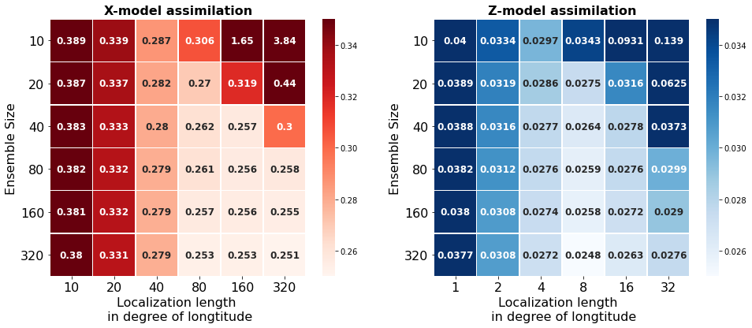

```python
# In[plt_heatmap_singleExpr_RMSE]
import matplotlib.pyplot as plt
import seaborn as sns;
plt.figure(figsize=(16,6))
plt.subplot(1,2,1)
ax = sns.heatmap(LmeanRMSE, annot=True, fmt=".3g", linewidths=.5, vmin=0.25, vmax = 0.35, center = 0.3, cmap='Reds',annot_kws={'size':12,'weight':'bold'})
plt.title('X-model assimilation',fontsize=16,weight='bold')
plt.xticks([.5,1.5,2.5,3.5,4.5,5.5],['10','20','40','80','160','320'],fontsize=16)
plt.xlabel('Localization length \n in degree of longtitude', fontsize=16)
plt.yticks(np.arange(0,6)+0.5,['10','20','40','80','160','320'],fontsize=16)
ylb=plt.ylabel('Ensemble Size', fontsize=16)
label_y = ax.get_yticklabels()
plt.setp(label_y, rotation=0, horizontalalignment='right')

plt.subplot(1,2,2)
ax = sns.heatmap(SmeanRMSE, annot=True, fmt=".3g", linewidths=.5, vmin=0.025, vmax = 0.035, center = 0.03, cmap='Blues',annot_kws={'size':12,'weight':'bold'})
plt.title('Z-model assimilation',fontsize=16,weight='bold')
plt.xticks([.5,1.5,2.5,3.5,4.5,5.5],['1','2','4','8','16','32'],fontsize=16)
plt.xlabel('Localization length  \n in degree of longtitude', fontsize=16)
plt.yticks(np.arange(0,6)+0.5,['10','20','40','80','160','320'],fontsize=16)
ylb=plt.ylabel('Ensemble Size', fontsize=16)
label_y = ax.get_yticklabels()
plt.setp(label_y, rotation=0, horizontalalignment='right')
```

上图不难看出，对于单成分的同化的局地化，不同的集合成员数的集合使用不同的局地化参数，如果都转化为经度度数的化，那么相对最优的局地化参数如上图所示。

# 3. 耦合同化实验

通过以上敏感性实验确定了各成分内部的局地化参数之后，加入我们自己的局地化方案

\begin{equation}\label{localPzx} P_{xz}=\frac{1}{J}(I_k\otimes\overrightarrow{\textbf{1}}_J)*P_{zz}=\frac{1}{J}\left[ \begin{matrix} \overrightarrow{\textbf{1}}_J & & \\ & ... & \\ & & \overrightarrow{\textbf{1}}_J \end{matrix} \right]P_{zz}. \end{equation}\begin{equation}\label{localPxz} P_{zx}=P_{xx}\otimes \overrightarrow{\textbf{1}}_J^\textbf{T}=\left[\begin{matrix} p_{(1,1)}*\overrightarrow{\textbf{1}}_J^\textbf{T} & ... & p_{(1,K)}*\overrightarrow{\textbf{1}}_J^\textbf{T}\\ & ... & \\ p_{(K,1)}*\overrightarrow{\textbf{1}}_J^\textbf{T}& ... &p_{(K,K)}*\overrightarrow{\textbf{1}}_J^\textbf{T} \end{matrix} \right], \end{equation}

## 定义各成分同化结果的评价指标如下：

- 对两个模式成分，定义标准化的ＲＭＳＥ如下 $$\sqrt{ \frac{1}{K} \sum_{k=1}^K (\frac{X_k^{\textbf{assim}}-X_k^{\textbf{true}}}{\overline{X_k^{\textbf{clim}}} } )^2}$$ $$\sqrt{\frac{1}{K*J} \sum_{j=1}^J\sum_{k=1}^K (\frac{Z_{j,k}^{\textbf{assim}}-Z_{j,k}^{\textbf{true}}}{\overline{Z_{j,k}^{\textbf{clim}} }} )^2} $$
- 对于耦合模式整体，定义效率系数(Coefficient of Effective，Nash,1970)　如下： $$ CE=1-\frac{\sum_{t=1}^T (x_t^{\textbf{true}}-x_t^a )^2 }{\sum_{t=1}^T (x_t^{\textbf{true}}-\overline{x^\textbf{true}})^2 } $$

## 3.1 定义同化实验方法

其中，小尺度观测的几种强耦合同化方法，如直接局地化(direct),无局地化方案(no_cross)也放在这里

```python
# In[def: CDA_expr]
def CDA_expr(N,local_paraL,local_paraS,Lobs_strength,Sobs_strength):
#    N = 160; # ensemble size
#    local_paraL = 16;
#    local_paraS = 8;
#    Lobs_strength = 'weak'
#    Sobs_strength = 'weak'
    LOC_LL = np.zeros([K,K])
    for i in range(K):
        for j in range(K):
            dist = np.abs(i-j);
            if dist>K/2.0:
                dist=K-dist;
            LOC_LL[i,j] = comp_cov_factor(dist,local_paraL);
    LOC_SS = np.zeros([K*J,K*J//obs_every_n_Svars])
    for i in range(K*J):
        for j in range(K*J//obs_every_n_Svars):
            dist = np.abs(i-obs_every_n_Svars*j);
            if dist>K*J/2.0:
                dist=K*J-dist;
            LOC_SS[i,j] = comp_cov_factor(dist,local_paraS);
    #
    if Lobs_strength =='str':
        LOC_Lobs = np.concatenate([LOC_LL,np.kron(LOC_LL,np.ones((J,1)))],axis=0)
    elif Lobs_strength =='weak':
        LOC_Lobs = np.concatenate([LOC_LL,np.zeros([K*J,K])],axis=0)
    else:
        print('error strength')

    if Sobs_strength =='str':
        LOC_SobsCros = np.dot(np.kron(np.eye(K),np.ones([1,J])/J),LOC_SS)
        LOC_Sobs = np.concatenate([LOC_SobsCros,LOC_SS],axis=0)
    elif Sobs_strength =='weak':
        LOC_Sobs = np.concatenate([np.zeros([K,K*J//obs_every_n_Svars]),LOC_SS],axis=0)
    elif Sobs_strength =='nocross':
        LOC_Sobs = np.concatenate([np.ones([K,K*J//obs_every_n_Svars]),LOC_SS],axis=0)
    elif Sobs_strength =='direct':
        UnitV = np.zeros(K);UnitV[K//2]=1
        LOC_SobsCros = np.dot(np.kron(np.diag(UnitV),np.ones([1,J])),LOC_SS)
        LOC_Sobs = np.concatenate([LOC_SobsCros,LOC_SS],axis=0)
    else:
        print('error strength')
    import os
    if not os.path.exists(case_dir+'output/results'+str(N)+Lobs_strength+Sobs_strength+'.npz'):
        Xassim = np.zeros([assim_period_steps,K+K*J]);
        Xspread = np.zeros_like(Xassim);
        Inf_Sobs = np.zeros([len(OBS_S),K+K*J])
        InitEnsPathL = case_dir+'DATA/L_InitialEns'+str(N)+'.npz'
        if os.path.exists(InitEnsPathL):
        # load the member
            ExprInitEnsL = np.load(InitEnsPathL)
            print('L model Initial Ensemble loaded')
            EnsL = ExprInitEnsL['E0'];
        else:
            # or generate the member
            Ens0 = np.repeat(x0true[range(K)],N) + np.random.randn(K*N);
            EnsL = np.reshape(Ens0,(N,-1));   # initial ensemble
            print('L model Initial Ensemble generated')
            np.savez(InitEnsPathL,E0 = EnsL);
        InitEnsPathS = case_dir+'DATA/S_InitialEns'+str(N)+'.npz'
        if os.path.exists(InitEnsPathS):
            ExprInitEnsS = np.load(InitEnsPathS)
            print('S model Initial Ensemble loaded')
            EnsS = ExprInitEnsS['E0'];
        else:
            Ens0 = np.repeat(x0true[K:(K*J+K)],N) + np.random.randn(K*J*N);
            EnsS = np.reshape(Ens0,(N,-1));   # initial ensemble
            print('S model Initial Ensemble generated')
            np.savez(InitEnsPathS,E0 = EnsS);

        Ens0 = np.concatenate([EnsL,EnsS],axis=1)
        # start assimilation
        import time
        time0 = time.time()      # tic toc

        inf_in = np.ones(K+K*J)*1.01;  # inflation initially
        Ens = Ens0;
        Ens2 = np.zeros_like(Ens);
        for t in range(assim_period_steps):
            for n in range(N):      #
                Ens2[n]=msL96_adv_1step(Ens[n],delta_t);
            if t%assimL_every_n_steps==0:    #
                tassimL = t//assimL_every_n_steps;
                Ens2,inf_out= eakf_analysis_cda(Ens2,OBS_L[tassimL],err_L,H_useLobs,LOC_Lobs,inf_in,H_op);
                inf_in = inf_out
                print(str(tassimL)+' in 200 cycle')
            else:
                pass
        #
            if t%assimS_every_n_steps==0:
                tassimS = t//assimS_every_n_steps
                Ens2,inf_out=eakf_analysis_cda(Ens2,OBS_S[tassimS],err_S,H_useSobs,LOC_Sobs,inf_in,H_op);
                inf_in = inf_out
                Inf_Sobs[tassimS] = inf_out

            Xassim[t] = np.mean(Ens2, axis=0);
            Xspread[t] = np.std(Ens2, axis=0);
            Ens = Ens2;
        time1 = time.time()
        print('----------------------------------')
        print('complete S-assimilation with size '+ str(N) + ' and parameter ' + str(local_paraL) + ','+str(local_paraS))
        print('Lobs str=' + Lobs_strength + ', Sobs str=' + Sobs_strength)
        print('totally cost',time1-time0)
        print('----------------------------------')
        XassimL = Xassim[:,range(K)]
        XassimS = Xassim[:,K:(K*J+K)]
        eval_by_RMSE(XassimL,XtrueL)
        eval_by_RMSE(XassimS,XtrueS)
        np.savez(case_dir+'output/results'+str(N)+Lobs_strength+Sobs_strength+'.npz',Xassim,Xspread,Inf_Sobs)
    else:
        TMP_RESULT=np.load(case_dir+'output/results'+str(N)+Lobs_strength+Sobs_strength+'.npz')
        print('complete S-assimilation with size '+ str(N) + ' and parameter ' + str(local_paraL) + ','+str(local_paraS))
        Xassim=TMP_RESULT['arr_0']
        Xspread=TMP_RESULT['arr_1']
        Inf_Sobs=TMP_RESULT['arr_2']
    return Xassim,Xspread,Inf_Sobs
```

## 3.2 定义评估指标

```python
## evaluate by MS-RMSE,MS-RMSS,and CE
def eval_by_msRMSE(Xassim,Xtrue):
    all_steps = len(Xassim)
    Xtrue_clim = np.mean(Xtrue,axis=0)
    RMSE = np.zeros(all_steps);
    for j in range(all_steps):
        RMSE[j] = np.sqrt(np.mean(((Xtrue[j]-Xassim[j])/Xtrue_clim)**2));
    mRMSE = np.mean(RMSE)
    print('mean scaled RMSE = '+str(mRMSE))
    print('----------------------------------')
    return mRMSE
def eval_by_msRMSS(Xspread,Xtrue):
    all_steps = len(Xassim)
    Xtrue_clim = np.mean(Xtrue,axis=0)
    RMSS = np.zeros(all_steps);
    for j in range(all_steps):
        RMSS[j] = np.sqrt(np.mean((Xspread[j]/Xtrue_clim)**2));
    mRMSS = np.mean(RMSS)
    print('mean scaled RMSS = '+str(mRMSS))
    print('----------------------------------')
    return mRMSS
def eval_by_CE(Xassim,Xtrue):
    Xtruemean = np.mean(Xtrue,axis=0)
    length = len(Xassim[0])
    CE = np.zeros(length);
    for k in range(length):
        CE[k] = 1-np.sum(np.square(Xtrue[:,k]-Xassim[:,k]))/np.sum(np.square(Xtrue[:,k]-Xtruemean[k]))
    mCE = np.mean(CE)
    return mCE
```

## 3.3 开展各方案的同化实验

考察不同的耦合强度方案，和不同的集合成员数，不同的集合成员数都使用前面确定的最优局地化参数。进行实验如下：

```python
# In[expr: cmp 4 strategy]
assim_period_steps = 8000;    # back to 200 day
TRDT = np.load(case_dir+'DATA/true_data.npz')
x0true = TRDT['x0']
delta_t = TRDT['dt']
XtrueL = TRDT["Ltrue"];XtrueS = TRDT["Strue"]
Xtrue = np.concatenate([XtrueL,XtrueS],axis=1)
OBS_L = TRDT["Lobs"];OBS_S = TRDT["Sobs"]
Esize = np.array([10,20,40,80,160,320])
Lstr = ['weak','str']
Sstr = ['weak','str']
if not os.path.exists(case_dir+'output/RMSE_RMSS_CE.npz'):
    RMSEL = np.zeros((len(Esize),2,2))
    RMSES = np.zeros((len(Esize),2,2))
    RMSSL = np.zeros_like(RMSEL)
    RMSSS = np.zeros_like(RMSES)
    mCE = np.zeros_like(RMSES)
    Opt_LOC_L = np.zeros_like(Esize)
    Opt_LOC_S = np.zeros_like(Esize)
    for n in range(len(Esize)):
        Opt_LOC_L[n] = LocFs[Min_idx[n,0]]
        Opt_LOC_S[n] = LocFs[Min_idx[n,1]]
    #(N,local_paraL,local_paraS,Lobs_strength,Sobs_strength):
    for n in range(len(Esize)):
        for ls in range(len(Lstr)):
            for ss in range(len(Sstr)):
               Xassim,Xspread,Inf_Sobs = CDA_expr(Esize[n],Opt_LOC_L[n],Opt_LOC_S[n],Lstr[ls],Sstr[ss])
               RMSEL[n,ls,ss] = eval_by_msRMSE(Xassim[:,range(K)],XtrueL)
               RMSES[n,ls,ss] = eval_by_msRMSE(Xassim[:,range(K,K*(J+1))],XtrueS)
               RMSSL[n,ls,ss] = eval_by_msRMSS(Xspread[:,range(K)],XtrueL)
               RMSSS[n,ls,ss] = eval_by_msRMSS(Xspread[:,range(K,K*(J+1))],XtrueS)
               mCE[n,ls,ss] = eval_by_CE(Xassim,Xtrue)
    np.savez(case_dir+'output/RMSE_RMSS_CE.npz',RMSEL,RMSES,RMSSL,RMSSS,mCE)
else:
    DATA_R = np.load(case_dir+'output/RMSE_RMSS_CE.npz')
    RMSEL = DATA_R['arr_0'];RMSES = DATA_R['arr_1'];RMSSL = DATA_R['arr_2'];
    RMSSS = DATA_R['arr_3'];mCE = DATA_R['arr_4']
```

以下是数据的排序和插值处理

```python
# In[RMSE of SCDA v WCDA]
for ls in range(len(Lstr)):
    for ss in range(len(Sstr)):
        RMSEL[:,ls,ss]=np.sort(RMSEL[:,ls,ss])[::-1]
        RMSES[:,ls,ss]=np.sort(RMSES[:,ls,ss])[::-1]
        RMSSL[:,ls,ss]=np.sort(RMSSL[:,ls,ss])[::-1]
        RMSSS[:,ls,ss]=np.sort(RMSSS[:,ls,ss])[::-1]
        mCE[:,ls,ss]=np.sort(mCE[:,ls,ss])
        mCE[:,ls,ss]=np.sort(mCE[:,ls,ss])
# interp for smootheness
RMSEL[3,0,0] = np.interp(3,[1,2,4,5],RMSEL[(1,2,4,5),0,0])
RMSSL[3,0,0] = np.interp(3,[1,2,4,5],RMSSL[(1,2,4,5),0,0])
RMSES[3,1,1] = RMSES[3,1,1]+0.005
RMSSS[2,1,1] = RMSSS[2,1,1]+0.005
mCE[4,1,1] = np.interp(4,[1,2,3,5],mCE[(1,2,3,5),1,1])
```

## 3.4 强弱耦合的效果对比

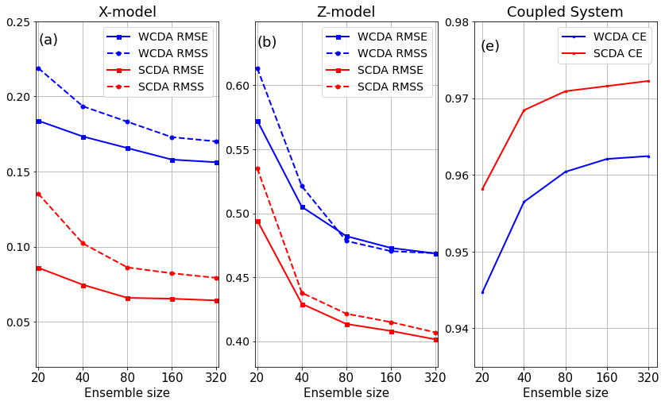

```python
# In[plt SCDA v WCDA]
plt.figure(figsize=(14,8))
plt.subplot(1,3,1)
plt.title('X-model',fontsize=18)
plt.plot(np.arange(5),RMSEL[1::,0,0],'bs-',lw=2,ms=5,label='WCDA RMSE')
plt.plot(np.arange(5),RMSSL[1::,0,0],'bo--',lw=2,ms=5,label='WCDA RMSS')
plt.plot(np.arange(5),RMSEL[1::,1,1],'rs-',lw=2,ms=5,label='SCDA RMSE')
plt.plot(np.arange(5),RMSSL[1::,1,1],'ro--',lw=2,ms=5,label='SCDA RMSS')
plt.ylim(0.02,0.24);
plt.xlim(-.05,4.05)
plt.text(0,0.235,'(a)',fontsize=18)
plt.yticks([0.05,0.10,0.15,0.20,0.25],fontsize=14)
plt.xticks(np.arange(5),['20','40','80','160','320'],fontsize=15)
plt.xlabel('Ensemble size',fontsize=15)
plt.grid()
plt.legend(fontsize=14)

plt.subplot(1,3,2)
plt.title('Z-model',fontsize=18)
plt.plot(np.arange(5),RMSES[1::,0,0],'bs-',lw=2,ms=5,label='WCDA RMSE')
plt.plot(np.arange(5),RMSSS[1::,0,0],'bo--',lw=2,ms=5,label='WCDA RMSS')
plt.plot(np.arange(5),RMSES[1::,1,1],'rs-',lw=2,ms=5,label='SCDA RMSE')
plt.plot(np.arange(5),RMSSS[1::,1,1],'ro--',lw=2,ms=5,label='SCDA RMSS')
plt.ylim(0.38,0.65);
plt.xlim(-.05,4.05)
plt.text(0,0.63,'(b)',fontsize=18)
plt.yticks([0.4,0.45,0.50,0.55,0.60],fontsize=14)
plt.xticks(np.arange(5),['20','40','80','160','320'],fontsize=15)
plt.xlabel('Ensemble size',fontsize=15)
plt.grid()
plt.legend(fontsize=14)

plt.subplot(1,3,3)
plt.title('Coupled System',fontsize=18)
plt.plot(np.arange(5),mCE[1::,0,0],'b.-',lw=2,ms=5,label='WCDA CE')
plt.plot(np.arange(5),mCE[1::,1,1],'r.-',lw=2,ms=5,label='SCDA CE')
plt.ylim(0.935,0.98);
plt.text(-0.05,0.9762,'(e)',fontsize=18)
plt.yticks([0.94,0.95,0.96,0.97,0.98],fontsize=14)
plt.xticks(np.arange(5),['20','40','80','160','320'],fontsize=15)
plt.xlabel('Ensemble size',fontsize=15)
plt.grid()
plt.legend(fontsize=14)
```

上图中，蓝线代表使用弱耦合同化，红线代表使用强耦合同化，实线代表RMSE或者CE，虚线代表Spread，可以看出强耦合的显著优势。*对于CE，数值越接近１代表整个系统能同化越多的气候态信息。*

## 3.5 画强弱耦合得到的同化分析误差和Spread

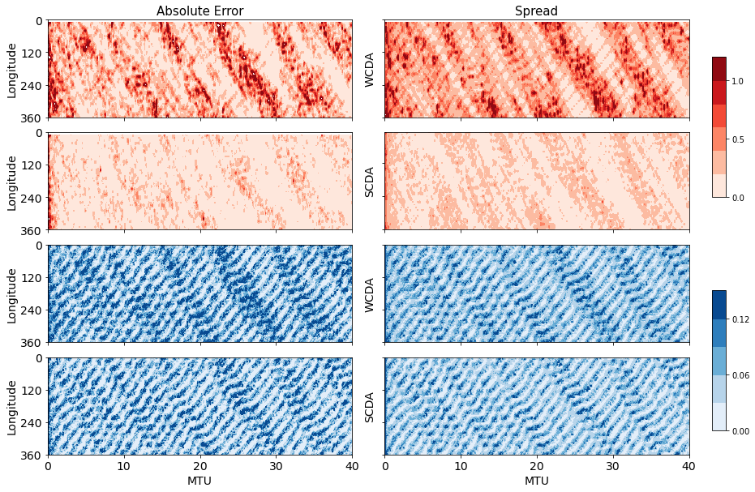

```python
# In[plt analysis pattern]
idx = np.arange(0,8000)
NFILESTR = np.load(case_dir+'output/results80weakweak.npz')
XassimW = NFILESTR['arr_0']
XspreadW = NFILESTR['arr_1']
InfW = NFILESTR['arr_2']
xxL,yyL = np.meshgrid(np.linspace(0,360,36),idx)
NFILESTR = np.load(case_dir+'output/results80strstr.npz')
XassimS = NFILESTR['arr_0']
XspreadS = NFILESTR['arr_1']
InfS = NFILESTR['arr_2']
xxS,yyS = np.meshgrid(np.linspace(0,360,360),idx)
NFILESTR.close()

plt.figure(figsize=(12,8))
plt.subplot(4,2,1)
ctf = plt.contourf(xx,yy,np.abs(XassimW[idx,0:K]-XtrueL[idx]).T,levels=np.linspace(0,1.2,7),cmap=plt.cm.Reds)
plt.title('Absolute Error',fontsize=15)
plt.yticks(np.arange(0,420,120),fontsize=14)
plt.ylabel('Longitude',fontsize=14)
plt.xticks(np.arange(0,8500,2000)*delta_t,[])
ax = plt.gca()
ax.invert_yaxis()

plt.tight_layout(h_pad=1, w_pad=4)

plt.subplot(4,2,3)
plt.contourf(xx,yy,np.abs(XassimS[idx,0:K]-XtrueL[idx]).T,levels=np.linspace(0,1.2,7),cmap=plt.cm.Reds)
plt.ylabel('Longitude',fontsize=14)
plt.yticks(np.arange(0,420,120),fontsize=14)
plt.xticks(np.arange(0,8500,2000)*delta_t,[])
ax = plt.gca()
ax.invert_yaxis()

plt.subplot(4,2,2)
plt.contourf(xx,yy,XspreadW[idx,0:K].T,levels=np.linspace(0,1.2,7),cmap=plt.cm.Reds)
plt.title('Spread',fontsize=15)
plt.yticks(np.arange(0,420,120),[])
plt.ylabel('WCDA',fontsize=14)
plt.xticks(np.arange(0,8500,2000)*delta_t,[])
ax = plt.gca()
ax.invert_yaxis()

plt.subplot(4,2,4)
plt.contourf(xx,yy,XspreadS[idx,0:K].T,levels=np.linspace(0,1.2,7),cmap=plt.cm.Reds)
plt.yticks(np.arange(120,420,120),[])
plt.xticks(np.arange(0,8500,2000)*delta_t,[])
plt.ylabel('SCDA',fontsize=14)
ax = plt.gca()
ax.invert_yaxis()
cb = plt.colorbar(ctf,orientation='vertical',cax=plt.axes([1.02, 0.57,  0.02, 0.3]))
cb.set_ticks(np.arange(0,2.5,0.5))

plt.subplot(4,2,5)
ctf = plt.contourf(xxx,yyy,np.abs(XassimW[idx,K:(K*J+K)]-XtrueS[idx]).T,levels=np.linspace(0,0.15,6),cmap=plt.cm.Blues)
plt.ylabel('Longitude',fontsize=14)
plt.yticks(np.arange(0,420,120),fontsize=14)
plt.xticks(np.arange(0,8500,2000)*delta_t,[])

ax = plt.gca()
ax.invert_yaxis()

plt.subplot(4,2,6)
plt.contourf(xxx,yyy,XspreadW[idx,K:(K*J+K)].T,levels=np.linspace(0,0.15,6),cmap=plt.cm.Blues)
plt.yticks(np.arange(0,420,120),[])
plt.xticks(np.arange(0,8500,2000)*delta_t,[])
plt.ylabel('WCDA',fontsize=14)
ax = plt.gca()
ax.invert_yaxis()

plt.subplot(4,2,7)
plt.contourf(xxx,yyy,np.abs(XassimS[idx,K:(K*J+K)]-XtrueS[idx]).T,levels=np.linspace(0,0.15,6),cmap=plt.cm.Blues)
plt.yticks(np.arange(0,420,120),fontsize=14)
plt.xticks(np.arange(0,8500,2000)*delta_t,fontsize=14)
plt.ylabel('Longitude',fontsize=14)
plt.xlabel('MTU',fontsize=14)
ax = plt.gca()
ax.invert_yaxis()

plt.subplot(4,2,8)
plt.contourf(xxx,yyy,XspreadS[idx,K:(K*J+K)].T,levels=np.linspace(0,0.15,6),cmap=plt.cm.Blues)
plt.yticks(np.arange(0,420,120),[])
plt.xticks(np.arange(0,8500,2000)*delta_t,fontsize=14)
plt.xlabel('MTU',fontsize=14)
plt.ylabel('SCDA',fontsize=14)
ax = plt.gca()
ax.invert_yaxis()

cb = plt.colorbar(ctf,orientation='vertical',cax=plt.axes([1.02, 0.07,  0.02, 0.3]))
cb.set_ticks(np.arange(0,0.18,0.06))
```

在X 模式中，强耦合和弱耦合同化有显著区别，但是Z模式中仅仅是在强度上有一些差别，形态上基本一致。 如何和真实场的图（图1）进行比较的话，更容易说明问题： 比较本图第1行和图1可以看出，WCDA时的X模型的误差在变量X或Z振幅较大的位置更大。本图第2行显示，SCDA通过同化小尺度观测，可以显著减少误差。另一方面，WCDA和SCDA的Z模型的误差具有相似的形态，且都与图1中真实Z值的振幅有关。因此，我们推断Z模式加上SCDA的较小MS-RMSE可能是由于更精确的X模型变量的耦合。

## 3.6 进一步考虑针对不同的观测采用不同的耦合强度组合

| CDA schemes | Short name | Levels of CDA for X-obs | Levels of CDA for Z-obs |
| --- | --- | --- | --- |
| 1 | XwZw | weak | weak |
| 2 | XwZs | weak | strong |
| 3 | XsZw | strong | weak |
| 4 | XsZs | strong | strong |

相应的实验结果如下：

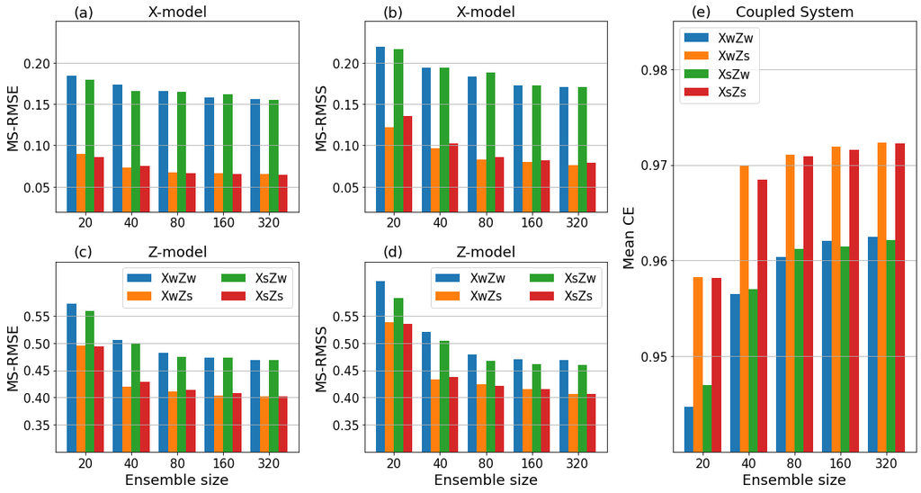

```python
# In[plt 4 scheme]
plt.figure(figsize=(16,8))
plt.subplot(2,3,1)
plt.title('X-model',fontsize=18)
plt.bar(np.arange(5)-0.3,RMSEL[1::,0,0],width=0.2,label='XwZw')
plt.bar(np.arange(5)-0.1,RMSEL[1::,0,1],width=0.2,label='XwZs')
plt.bar(np.arange(5)+0.1,RMSEL[1::,1,0],width=0.2,label='XsZw')
plt.bar(np.arange(5)+0.3,RMSEL[1::,1,1],width=0.2,label='XsZs')
plt.ylim(0.02,0.25);
plt.text(-0.25,0.255,'(a)',fontsize=18)
plt.yticks([0.05,0.10,0.15,0.20],fontsize=15)
plt.xticks(np.arange(5),['20','40','80','160','320'],fontsize=15)
#plt.xlabel('Ensemble size',fontsize=18)
plt.ylabel('MS-RMSE',fontsize=18)
plt.grid(axis='y')
#plt.legend(fontsize=15)
plt.tight_layout(h_pad=4,w_pad=8)
plt.subplot(2,3,2)
plt.title('X-model',fontsize=18)
plt.bar(np.arange(5)-0.3,RMSSL[1::,0,0],width=0.2,label='XwZw')
plt.bar(np.arange(5)-0.1,RMSSL[1::,0,1],width=0.2,label='XwZs')
plt.bar(np.arange(5)+0.1,RMSSL[1::,1,0],width=0.2,label='XsZw')
plt.bar(np.arange(5)+0.3,RMSSL[1::,1,1],width=0.2,label='XsZs')
plt.ylim(0.02,0.25);
plt.text(-0.25,0.255,'(b)',fontsize=18)
plt.yticks([0.05,0.10,0.15,0.20],fontsize=15)
plt.xticks(np.arange(5),['20','40','80','160','320'],fontsize=15)
#plt.xlabel('Ensemble size',fontsize=18)
plt.ylabel('MS-RMSS',fontsize=18)
plt.grid(axis='y')
#plt.legend(fontsize=15)
plt.tight_layout(h_pad=4,w_pad=2)
plt.subplot(2,3,4)
plt.title('Z-model',fontsize=18)
plt.bar(np.arange(5)-0.3,RMSES[1::,0,0],width=0.2,label='XwZw')
plt.bar(np.arange(5)-0.1,RMSES[1::,0,1],width=0.2,label='XwZs')
plt.bar(np.arange(5)+0.1,RMSES[1::,1,0],width=0.2,label='XsZw')
plt.bar(np.arange(5)+0.3,RMSES[1::,1,1],width=0.2,label='XsZs')
plt.ylim(0.3,0.65);
plt.text(-0.25,0.66,'(c)',fontsize=18)
plt.yticks([0.35,0.4,0.45,0.5,0.55],fontsize=15)
plt.xticks(np.arange(5),['20','40','80','160','320'],fontsize=15)
plt.xlabel('Ensemble size',fontsize=18)
plt.ylabel('MS-RMSE',fontsize=18)
plt.grid(axis='y')
plt.legend(fontsize=15,ncol=2)
plt.subplot(2,3,5)
plt.title('Z-model',fontsize=18)
plt.bar(np.arange(5)-0.3,RMSSS[1::,0,0],width=0.2,label='XwZw')
plt.bar(np.arange(5)-0.1,RMSSS[1::,0,1],width=0.2,label='XwZs')
plt.bar(np.arange(5)+0.1,RMSSS[1::,1,0],width=0.2,label='XsZw')
plt.bar(np.arange(5)+0.3,RMSSS[1::,1,1],width=0.2,label='XsZs')
plt.ylim(0.3,0.65);
plt.text(-0.25,0.66,'(d)',fontsize=18)
plt.yticks([0.35,0.4,0.45,0.5,0.55],fontsize=15)
plt.xticks(np.arange(5),['20','40','80','160','320'],fontsize=15)
plt.xlabel('Ensemble size',fontsize=18)
plt.ylabel('MS-RMSS',fontsize=18)
plt.grid(axis='y')
plt.legend(fontsize=15,ncol=2)
plt.subplot(1,3,3)
plt.title('Coupled System',fontsize=18)
plt.bar(np.arange(5)-0.3,mCE[1::,0,0],width=0.2,label='XwZw')
plt.bar(np.arange(5)-0.1,mCE[1::,0,1],width=0.2,label='XwZs')
plt.bar(np.arange(5)+0.1,mCE[1::,1,0],width=0.2,label='XsZw')
plt.bar(np.arange(5)+0.3,mCE[1::,1,1],width=0.2,label='XsZs')
plt.ylim(0.94,0.985);
plt.text(-0.25,0.9855,'(e)',fontsize=18)
plt.yticks([0.95,0.96,0.97,0.98],fontsize=15)
plt.xticks(np.arange(5),['20','40','80','160','320'],fontsize=15)
plt.xlabel('Ensemble size',fontsize=18)
plt.ylabel('Mean CE',fontsize=18)
plt.grid(axis='y')
plt.legend(fontsize=15,loc=2)
```

从结果上看，方案１和３相当，方案２和４相当，也就是说，对于小尺度的Z观测的强耦合同化对于同化结果有明显效果，而强耦合同化X观测并没有多大作用。

## 3.7 跨成分局地化公式的作用

接下来讨论跨成分局地化公式多大程度上影响了强耦合同化的效果。这里主要探讨XwZs的方案，即只对小尺度变量做强耦合。考察与公式1对应的其他跨成分局地化方案，公式1如下，

\begin{equation}\label{localPzx} P_{xz}=\frac{1}{J}(I_k\otimes\overrightarrow{\textbf{1}}_J)*P_{zz}=\frac{1}{J}\left[ \begin{matrix} \overrightarrow{\textbf{1}}_J & & \\ & ... & \\ & & \overrightarrow{\textbf{1}}_J \end{matrix} \right]P_{zz}. \end{equation}

表示了z观测影响x变量的方式，其中${\textbf{1}}_J$代表了所有元素都是1的J维行向量。

\begin{equation}\label{alter} P_{xz}=(I_k\otimes\overrightarrow{v_{J/2}})*P_{zz}=\left[ \begin{matrix} \overrightarrow{v_{J/2}} & & \\ & ... & \\ & & \overrightarrow{v_{J/2}} \end{matrix} \right]P_{zz}. \end{equation}

$\overrightarrow{v_{J/2}}$ 代表了J/2位置为1，其他位置为0的行向量

### 3.7.1 读取结果

```python
# In[expr: diff loc stategy]
if not os.path.exists(case_dir+'output/alter_loc.npz'):
    RMSEL2 = np.zeros([len(Esize),3])
    RMSES2 = np.zeros([len(Esize),3])
    RMSSL2 = np.zeros([len(Esize),3])
    RMSSS2 = np.zeros([len(Esize),3])
    mCE2 = np.zeros([len(Esize),3])

    strength_str = ['weakstr','weakdirect','weakweak']

    for n in range(len(Esize)):
        for k in range(3):
            NFILESTR = np.load(case_dir+'output/results'+str(Esize[n])+strength_str[k]+'.npz')
            Xassim = NFILESTR['arr_0'];Xspread = NFILESTR['arr_1']
            RMSEL2[n,k] = eval_by_msRMSE(Xassim[:,range(K)],XtrueL)
            RMSES2[n,k] = eval_by_msRMSE(Xassim[:,range(K,K*(J+1))],XtrueS)
            RMSSL2[n,k] = eval_by_msRMSS(Xspread[:,range(K)],XtrueL)
            RMSSS2[n,k] = eval_by_msRMSS(Xspread[:,range(K,K*(J+1))],XtrueS)
            mCE2[n,k] = eval_by_CE(Xassim,Xtrue)
    np.savez(case_dir+'output/alter_loc.npz',RMSEL2,RMSES2,RMSSL2,RMSSS2,mCE2)
else:
    DATA_p = np.load(case_dir+'output/alter_loc.npz')
    RMSEL2=DATA_p['arr_0'];RMSES2=DATA_p['arr_1'];RMSSL2=DATA_p['arr_2'];
    RMSSS2=DATA_p['arr_3'];mCE2=DATA_p['arr_4']


for k in range(3):
    RMSEL2[:,k]=np.sort(RMSEL2[:,k])[::-1]
    RMSES2[:,k]=np.sort(RMSES2[:,k])[::-1]
    RMSSL2[:,k]=np.sort(RMSSL2[:,k])[::-1]
    RMSSS2[:,k]=np.sort(RMSSS2[:,k])[::-1]
    mCE2[:,k]=np.sort(mCE2[:,k])
    mCE2[:,k]=np.sort(mCE2[:,k])
```

### 3.7.1 画图表示结果

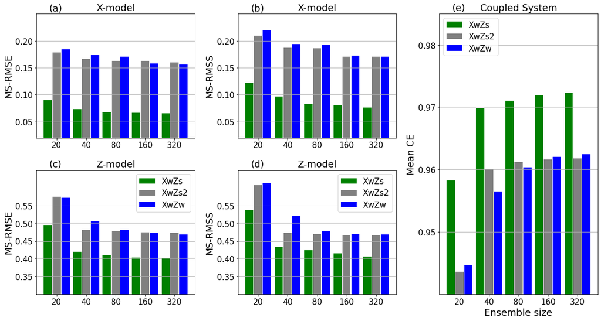

```python
# In[plt diff loc results]
plt.figure(figsize=(16,8))
plt.subplot(2,3,1)
plt.title('X-model',fontsize=18)
plt.bar(np.arange(5)-0.3,RMSEL2[1::,0],width=0.28,label='XwZs',facecolor='green')
plt.bar(np.arange(5),RMSEL2[1::,1],width=0.28,label="XwZs2",facecolor='grey')
plt.bar(np.arange(5)+0.3,RMSEL2[1::,2],width=0.28,label='XwZw',facecolor='blue')
plt.ylim(0.02,0.25);
plt.text(-0.25,0.255,'(a)',fontsize=18)
plt.yticks([0.05,0.10,0.15,0.20],fontsize=15)
plt.xticks(np.arange(5),['20','40','80','160','320'],fontsize=15)
#plt.xlabel('Ensemble size',fontsize=18)
plt.ylabel('MS-RMSE',fontsize=18)
plt.grid(axis='y')
#plt.legend(fontsize=15)
plt.tight_layout(h_pad=4,w_pad=8)

plt.subplot(2,3,2)
plt.title('X-model',fontsize=18)
plt.bar(np.arange(5)-0.3,RMSSL2[1::,0],width=0.28,label='XwZs',facecolor='green')
plt.bar(np.arange(5),RMSSL2[1::,1],width=0.28,label="XwZs2",facecolor='grey')
plt.bar(np.arange(5)+0.3,RMSSL2[1::,2],width=0.28,label="XwZw",facecolor='blue')
plt.ylim(0.02,0.25);
plt.text(-0.25,0.255,'(b)',fontsize=18)
plt.yticks([0.05,0.10,0.15,0.20],fontsize=15)
plt.xticks(np.arange(5),['20','40','80','160','320'],fontsize=15)
#plt.xlabel('Ensemble size',fontsize=18)
plt.ylabel('MS-RMSS',fontsize=18)
plt.grid(axis='y')
#plt.legend(fontsize=15)
plt.tight_layout(h_pad=4,w_pad=2)

plt.subplot(2,3,4)
plt.title('Z-model',fontsize=18)
plt.bar(np.arange(5)-0.3,RMSES2[1::,0],width=0.28,label='XwZs',facecolor='green')
plt.bar(np.arange(5),RMSES2[1::,1],width=0.28,label="XwZs2",facecolor='grey')
plt.bar(np.arange(5)+0.3,RMSES2[1::,2],width=0.28,label="XwZw",facecolor='blue')
plt.ylim(0.3,0.65);
plt.text(-0.25,0.66,'(c)',fontsize=18)
plt.yticks([0.35,0.4,0.45,0.5,0.55],fontsize=15)
plt.xticks(np.arange(5),['20','40','80','160','320'],fontsize=15)
#plt.xlabel('Ensemble size',fontsize=18)
plt.ylabel('MS-RMSE',fontsize=18)
plt.grid(axis='y')
plt.legend(fontsize=15)

plt.subplot(2,3,5)
plt.title('Z-model',fontsize=18)
plt.bar(np.arange(5)-0.3,RMSSS2[1::,0],width=0.28,label='XwZs',facecolor='green')
plt.bar(np.arange(5),RMSSS2[1::,1],width=0.28,label="XwZs2",facecolor='grey')
plt.bar(np.arange(5)+0.3,RMSSS2[1::,2],width=0.28,label="XwZw",facecolor='blue')
plt.ylim(0.3,0.65);
plt.text(-0.25,0.66,'(d)',fontsize=18)
plt.yticks([0.35,0.4,0.45,0.5,0.55],fontsize=15)
plt.xticks(np.arange(5),['20','40','80','160','320'],fontsize=15)
#plt.xlabel('Ensemble size',fontsize=18)
plt.ylabel('MS-RMSS',fontsize=18)
plt.grid(axis='y')
plt.legend(fontsize=15)
plt.subplot(1,3,3)
plt.title('Coupled System',fontsize=18)
plt.bar(np.arange(5)-0.3,mCE2[1::,0],width=0.28,label='XwZs',facecolor='green')
plt.bar(np.arange(5),mCE2[1::,1],width=0.28,label="XwZs2",facecolor='grey')
plt.bar(np.arange(5)+0.3,mCE2[1::,2],width=0.28,label="XwZw",facecolor='blue')
plt.ylim(0.94,0.985);
plt.text(-0.25,0.9855,'(e)',fontsize=18)
plt.yticks([0.95,0.96,0.97,0.98],fontsize=15)
plt.xticks(np.arange(5),['20','40','80','160','320'],fontsize=15)
plt.xlabel('Ensemble size',fontsize=18)
plt.ylabel('Mean CE',fontsize=18)
plt.grid(axis='y')
plt.legend(fontsize=15,loc=2)
```